# PCA - Multiple Linear Regression

Author

Hector Gavilanes

## Libraries

```r
# Load necessary libraries
library(tidyverse)    # for handling missing values
library(EnvStats) # for rosnerTest
library(caTools)
library(caret)
library(corrplot)
library(Metrics)
library(car)        # for outliers test
library(corrr)      # correlation matrix
library(ggcorrplot) # correlation graph
library(FactoMineR) # PCA analysis
library(factoextra) # PCA plots
library(pls)        # PC regression
library(e1071)      # to fit transform PCA
# library(plotly)
```

# 01 - Data Preparation

```r
# clear environment
rm(list = ls())

# Load dataset
train_original <- read.csv('../dataset/DFC_STATE.csv')

# Make a working copy
train_data <- train_original

# Constant seed
my_seed = 95
```

## Rename Variables

```r
train_data <- rename(train_data,
                      better_transfusion = Transfusions..Better.than.expected..STATE.,
        expected_transfusion = Transfusions..As.expected..STATE.,
        worse_transfusion = Transfusions..Worse.than.expected..STATE.,
        better_infection = Infection..Better.than.expected..STATE.,
        expected_infection = Infection..As.expected..STATE.,
        worse_infection = Infection..Worse.than.expected..STATE.,
        Kt_v_1.2 = Percentage.of.adult.HD.patients.with.Kt.V..1.2,
        Kt_v_1.7 = Percentage.Of.Adult.PD.Patients.With.Kt.V..1.7,
        pedriatic_Kt_v_1.2 = Percentage.Of.Pediatric.HD.Patients.With.Kt.V..1.2,
        pediatric_Kt_v_1.8 = Percentage.Of.Pediatric.PD.Patients.With.Kt.V..1.8,
        pediatric_nPCR = Percentage.Of.Pediatric.HD.Patients.With.nPCR.In.Use,
        better_fistula = Fistula.Rate...Better.Than.Expected..STATE.,
        expected_fistula = Fistula.Rate...As.Expected..STATE.,
        worse_fistula = Fistula.Rate...Worse.Than.Expected..STATE.,
        long_term_catheter = Percentage.Of.Adult.Patients.With.Long.Term.Catheter.In.Use ,
        "hypercalcemia_calcium > 10.2Mg" = Percentage.Of.Adult.Patients.With.Hypercalcemia..Serum.Calcium.Greater.Than.10.2.Mg.dL.,
        "phosphorus < 3.5Mg" = Percentage.Of.Adult.Patients.With.Serum.Phosphorus.Less.Than.3.5.Mg.dL,
        "phosphorus (3.5 - 4.5) Mg" = Percentage.Of.Adult.Patients.With.Serum.Phosphorus.Between.3.5.4.5.Mg.dL,
        "phosphorus (4.6 - 5.5) Mg" = Percentage.Of.Adult.Patients.With.Serum.Phosphorus.Between.4.6.5.5.Mg.dL,
        "phosphorus (5.6 - 7) Mg" = Percentage.Of.Adult.Patients.With.Serum.Phosphorus.Between.5.6.7.0.Mg.dL,
        "phosphorus > 7Mg" = Percentage.Of.Adult.Patients.With.Serum.Phosphorus.Greater.Than.7.0.Mg.dL,
        better_hospitalization = Hospitalizations..Better.Than.Expected..STATE.,
        expected_hospitalization = Hospitalizations..As.Expected..STATE.,
        worse_hospitalization = Hospitalizations..Worse.Than.Expected..STATE.,
        better_hospital_readmission = Hospital.Readmission...Better.Than.Expected..STATE.,
        expected_hospital_readmission = Hospital.Readmission...As.Expected..STATE.,
        worse_hospital_readmission = Hospital..Readmission...Worse.Than.Expected..STATE.,
        better_survival = Survival..Better.Than.Expected..STATE.,
        expected_survival = Survival..As.Expected..STATE.,
        worse_survival = Survival..Worse.Than.Expected..STATE.,
        incident_transplant_waitlist_better = Incident.Patients.Transplant.Waitlisting..Better.Than.Expected..STATE.,
        incident_transplant_waitlist_expected = Incident.Patients.Transplant.Waitlisting...As.Expected..STATE.,
        incident_transplant_waitlist_worse = Incident.Patients.Transplant.Waitlisting...Worse.Than.Expected..STATE.,
        prevalent_transplant_waitlist_better = Prevalent.Patients.Transplant.Waitlisting..Better.Than.Expected..STATE.,
        prevalent_transplant_waitlist_expected = Prevalent.Patients.Transplant.Waitlisting...As.Expected..STATE.,
        prevalent_transplant_waitlist_worse = Prevalent.Patients.Transplant.Waitlisting...Worse.Than.Expected..STATE.,
        "Hgb 10g"= Percentage.Of.Patients.With.Hgb.10.g.dL,
        "Hgb 12g" = Percentage.of.patients.with.Hgb.12.g.dL
        )
```

## Impute Missing Values

- Replace missing values with the mean.

```r
# Count the number of missing values in each column
colSums(is.na(train_data))
```

```
                                 State                     better_transfusion
                                     0                                      0
                  expected_transfusion                      worse_transfusion
                                     0                                      0
                      better_infection                     expected_infection
                                     0                                      0
                       worse_infection                               Kt_v_1.2
                                     0                                      1
                              Kt_v_1.7                     pedriatic_Kt_v_1.2
                                     2                                      7
                    pediatric_Kt_v_1.8                         pediatric_nPCR
                                    10                                      5
                        better_fistula                       expected_fistula
                                     0                                      0
                         worse_fistula                     long_term_catheter
                                     0                                      1
        hypercalcemia_calcium > 10.2Mg                     phosphorus < 3.5Mg
                                     1                                      1
             phosphorus (3.5 - 4.5) Mg              phosphorus (4.6 - 5.5) Mg
                                     1                                      1
               phosphorus (5.6 - 7) Mg                       phosphorus > 7Mg
                                     1                                      1
                better_hospitalization               expected_hospitalization
                                     0                                      0
                 worse_hospitalization            better_hospital_readmission
                                     0                                      0
         expected_hospital_readmission             worse_hospital_readmission
                                     0                                      0
                       better_survival                      expected_survival
                                     0                                      0
                        worse_survival    incident_transplant_waitlist_better
                                     0                                      0
 incident_transplant_waitlist_expected     incident_transplant_waitlist_worse
                                     0                                      0
  prevalent_transplant_waitlist_better prevalent_transplant_waitlist_expected
                                     0                                      0
   prevalent_transplant_waitlist_worse                                Hgb 10g
                                     0                                      1
                               Hgb 12g
                                     1
```

```r
# Remove categorical columns
train_data$State <- NULL

# Impute missing values with the mean
for (col in colnames(train_data)) {
  mean_value <- mean(train_data[[col]], na.rm = TRUE)
  train_data[[col]] <- ifelse(is.na(train_data[[col]]), mean_value,     train_data[[col]])
}
```

```r
# Remove rows with missing values
train_data <- na.omit(train_data)

# Count the number of missing values in each column
colSums(is.na(train_data))
```

```
                    better_transfusion                   expected_transfusion
                                     0                                      0
                     worse_transfusion                       better_infection
                                     0                                      0
                    expected_infection                        worse_infection
                                     0                                      0
                              Kt_v_1.2                               Kt_v_1.7
                                     0                                      0
                    pedriatic_Kt_v_1.2                     pediatric_Kt_v_1.8
                                     0                                      0
                        pediatric_nPCR                         better_fistula
                                     0                                      0
                      expected_fistula                          worse_fistula
                                     0                                      0
                    long_term_catheter         hypercalcemia_calcium > 10.2Mg
                                     0                                      0
                    phosphorus < 3.5Mg              phosphorus (3.5 - 4.5) Mg
                                     0                                      0
             phosphorus (4.6 - 5.5) Mg                phosphorus (5.6 - 7) Mg
                                     0                                      0
                      phosphorus > 7Mg                 better_hospitalization
                                     0                                      0
              expected_hospitalization                  worse_hospitalization
                                     0                                      0
           better_hospital_readmission          expected_hospital_readmission
                                     0                                      0
            worse_hospital_readmission                        better_survival
                                     0                                      0
                     expected_survival                         worse_survival
                                     0                                      0
   incident_transplant_waitlist_better  incident_transplant_waitlist_expected
                                     0                                      0
    incident_transplant_waitlist_worse   prevalent_transplant_waitlist_better
                                     0                                      0
prevalent_transplant_waitlist_expected    prevalent_transplant_waitlist_worse
                                     0                                      0
                               Hgb 10g                                Hgb 12g
                                     0                                      0
```

```r
# Get duplicated rows
train_data[duplicated(train_data), ]
```

```
 [1] better_transfusion
 [2] expected_transfusion
 [3] worse_transfusion
 [4] better_infection
 [5] expected_infection
 [6] worse_infection
 [7] Kt_v_1.2
 [8] Kt_v_1.7
 [9] pedriatic_Kt_v_1.2
[10] pediatric_Kt_v_1.8
[11] pediatric_nPCR
[12] better_fistula
[13] expected_fistula
[14] worse_fistula
[15] long_term_catheter
```

[output cut: 24 more lines]

```r
# Summary statistics of the data
summary(train_data)
```

```
 better_transfusion expected_transfusion worse_transfusion better_infection
 Min.   :0.0000     Min.   :  1.00       Min.   : 0.000    Min.   :  0.00
 1st Qu.:0.0000     1st Qu.: 22.75       1st Qu.: 1.000    1st Qu.:  5.75
 Median :0.0000     Median : 53.00       Median : 3.000    Median : 22.00
 Mean   :0.1786     Mean   : 99.23       Mean   : 7.286    Mean   : 40.00
 3rd Qu.:0.0000     3rd Qu.:134.25       3rd Qu.:10.250    3rd Qu.: 51.00
 Max.   :2.0000     Max.   :596.00       Max.   :47.000    Max.   :290.00
 expected_infection worse_infection    Kt_v_1.2       Kt_v_1.7
 Min.   :  0.0      Min.   :0.000   Min.   :87.0   Min.   :69.00
 1st Qu.: 13.0      1st Qu.:0.000   1st Qu.:96.0   1st Qu.:90.00
 Median : 47.5      Median :0.000   Median :97.0   Median :93.00
 Mean   : 74.0      Mean   :1.143   Mean   :96.4   Mean   :91.72
 3rd Qu.:105.5      3rd Qu.:2.000   3rd Qu.:97.0   3rd Qu.:94.00
 Max.   :397.0      Max.   :8.000   Max.   :99.0   Max.   :96.00
 pedriatic_Kt_v_1.2 pediatric_Kt_v_1.8 pediatric_nPCR   better_fistula
 Min.   : 47.00     Min.   :  0.00     Min.   : 15.00   Min.   : 0.000
 1st Qu.: 87.75     1st Qu.: 66.75     1st Qu.: 90.75   1st Qu.: 0.000
 Median : 91.20     Median : 75.27     Median : 94.00   Median : 2.000
 Mean   : 91.20     Mean   : 74.54     Mean   : 91.02   Mean   : 4.929
 3rd Qu.:100.00     3rd Qu.: 92.00     3rd Qu.:100.00   3rd Qu.: 5.250
 Max.   :100.00     Max.   :100.00     Max.   :100.00   Max.   :50.000
 expected_fistula worse_fistula   long_term_catheter
 Min.   :  0.00   Min.   : 0.00   Min.   :10.00
 1st Qu.: 25.25   1st Qu.: 0.00   1st Qu.:15.00
 Median : 66.00   Median : 1.00   Median :17.00
 Mean   :116.57   Mean   : 5.25   Mean   :17.02
 3rd Qu.:157.75   3rd Qu.: 6.50   3rd Qu.:18.00
 Max.   :659.00   Max.   :40.00   Max.   :29.00
 hypercalcemia_calcium > 10.2Mg phosphorus < 3.5Mg phosphorus (3.5 - 4.5) Mg
 Min.   : 1.0                   Min.   : 5.0       Min.   :11.00
 1st Qu.: 1.0                   1st Qu.: 7.0       1st Qu.:22.00
 Median : 2.0                   Median : 8.0       Median :23.00
 Mean   : 2.4                   Mean   : 7.6       Mean   :23.13
 3rd Qu.: 2.0                   3rd Qu.: 8.0       3rd Qu.:24.00
 Max.   :33.0                   Max.   :11.0       Max.   :27.00
 phosphorus (4.6 - 5.5) Mg phosphorus (5.6 - 7) Mg phosphorus > 7Mg
 Min.   :24.00             Min.   :20.00           Min.   : 8.00
 1st Qu.:28.00             1st Qu.:23.00           1st Qu.:15.00
 Median :29.00             Median :24.00           Median :16.23
 Mean   :29.09             Mean   :23.71           Mean   :16.45
```

[output cut: 36 more lines]

```
 Max.   :34.000                     Max.   :168.000
 prevalent_transplant_waitlist_expected prevalent_transplant_waitlist_worse
 Min.   :  0.0                          Min.   : 0.000
 1st Qu.: 27.5                          1st Qu.: 0.000
 Median : 63.0                          Median : 2.000
 Mean   :120.9                          Mean   : 2.893
 3rd Qu.:166.5                          3rd Qu.: 4.250
 Max.   :714.0                          Max.   :18.000
    Hgb 10g         Hgb 12g
 Min.   : 9.00   Min.   :0.00000
 1st Qu.:18.00   1st Qu.:0.00000
 Median :20.50   Median :0.00000
 Mean   :21.47   Mean   :0.23636
 3rd Qu.:23.00   3rd Qu.:0.05909
 Max.   :60.00   Max.   :1.00000
```

```r
# Summary statistics of categorical variables
summary(train_data[, sapply(train_data, is.character)])
```

```
< table of extent 0 x 0 >
```

```r
# Check dataset structure
str(train_data)
```

```
'data.frame':   56 obs. of  38 variables:
 $ better_transfusion                    : int  0 0 0 0 0 2 0 0 0 0 ...
 $ expected_transfusion                  : int  7 133 41 2 99 596 52 41 18 24 ...
 $ worse_transfusion                     : int  1 10 16 0 3 15 4 5 0 1 ...
 $ better_infection                      : int  3 39 24 0 50 290 20 13 6 13 ...
 $ expected_infection                    : int  6 116 35 0 68 298 52 34 13 13 ...
 $ worse_infection                       : int  0 0 0 0 0 1 1 0 0 0 ...
 $ Kt_v_1.2                              : num  97 96 96 96.4 97 97 98 96 97 98 ...
 $ Kt_v_1.7                              : num  93 94 91 91.7 94 ...
 $ pedriatic_Kt_v_1.2                    : num  100 88 95 91.2 98 ...
 $ pediatric_Kt_v_1.8                    : num  74.5 81 97 74.5 86 ...
 $ pediatric_nPCR                        : num  100 88 93 91 99 ...
 $ better_fistula                        : int  1 8 2 1 3 44 12 7 0 0 ...
 $ expected_fistula                      : int  8 148 59 0 119 593 68 39 19 30 ...
 $ worse_fistula                         : int  0 14 4 1 0 12 0 1 0 1 ...
```

[output cut: 24 more lines]

# 02 - Feature Scaling

- Standardization ensures all features are on the same scale, and this method is less sensitive to outliers.

```r
# Find the index position of the target feature
target_name <- "expected_survival"
target_index <- grep(target_name,
                     colnames(train_data))
```

```r
# Standardization Numerical Features
train_data_sc <- scale(train_data[, -target_index])
```

# 03 - PCA Analysis

## Outliers Detection

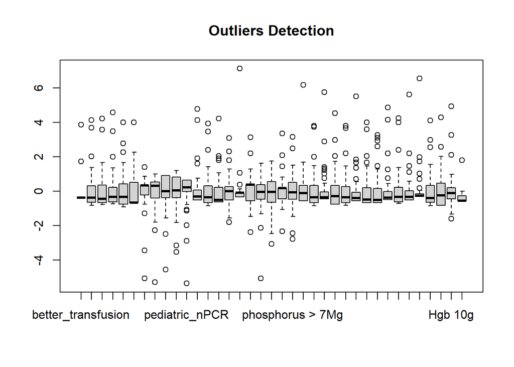

```r
# Plot a boxplot to visualize potential outliers
boxplot(train_data_sc, main = "Outliers Detection")
```

## Correlations

- There are high correlated features.
- Multicollinearity is present in the data set

```r
# Calculate correlations and round to 2 digits
corr_matrix <- cor(train_data_sc)
corr_matrix <- round(corr_matrix, digits = 2)

# Print names of highly correlated features; threshold > 0.30
high <- findCorrelation(corr_matrix, cutoff = 0.30, names = TRUE)
high
```

```
 [1] "expected_transfusion"
 [2] "better_infection"
 [3] "expected_hospitalization"
 [4] "expected_hospital_readmission"
 [5] "expected_fistula"
 [6] "prevalent_transplant_waitlist_expected"
 [7] "incident_transplant_waitlist_expected"
 [8] "expected_infection"
 [9] "worse_survival"
[10] "incident_transplant_waitlist_better"
[11] "better_hospital_readmission"
[12] "worse_transfusion"
[13] "worse_hospital_readmission"
[14] "worse_fistula"
[15] "incident_transplant_waitlist_worse"
[16] "better_fistula"
[17] "prevalent_transplant_waitlist_better"
[18] "better_survival"
[19] "worse_infection"
[20] "phosphorus (5.6 - 7) Mg"
[21] "prevalent_transplant_waitlist_worse"
[22] "phosphorus (3.5 - 4.5) Mg"
[23] "phosphorus > 7Mg"
[24] "better_transfusion"
[25] "Hgb 10g"
[26] "hypercalcemia_calcium > 10.2Mg"
[27] "pediatric_nPCR"
[28] "long_term_catheter"
```

## Full Model Regression

- The Adjusted R^2 = 99.99% is an indication of over-fitting, or bias.

```r
set.seed(my_seed)

# Fit a multiple linear regression model
full_model <- lm(expected_survival ~ ., data = train_data)

# Print a summary of the regression model
summary(full_model)
```

```
Call:
lm(formula = expected_survival ~ ., data = train_data)

Residuals:
     Min       1Q   Median       3Q      Max
-1.44543 -0.31575 -0.05481  0.39273  1.13134

Coefficients:
                                         Estimate Std. Error t value Pr(>|t|)
(Intercept)                            93.7141729 41.8771301   2.238 0.038114
better_transfusion                      1.0433623  0.7504271   1.390 0.181374
expected_transfusion                    0.0011165  0.0339108   0.033 0.974098
worse_transfusion                       0.1321425  0.0752163   1.757 0.095943
better_infection                       -0.2665210  0.0913321  -2.918 0.009178
expected_infection                     -0.0353924  0.0617830  -0.573 0.573833
worse_infection                        -0.1114838  0.2720510  -0.410 0.686796
Kt_v_1.2                                0.2515467  0.2538274   0.991 0.334814
Kt_v_1.7                               -0.0002502  0.0523052  -0.005 0.996236
pedriatic_Kt_v_1.2                     -0.0399970  0.0330110  -1.212 0.241322
pediatric_Kt_v_1.8                     -0.0179608  0.0095227  -1.886 0.075523
pediatric_nPCR                          0.0444777  0.0254264   1.749 0.097275
better_fistula                         -0.1839466  0.1065136  -1.727 0.101292
expected_fistula                        0.0061566  0.0750108   0.082 0.935492
worse_fistula                          -0.0301080  0.1060795  -0.284 0.779783
long_term_catheter                      0.3116122  0.0743814   4.189 0.000551
`hypercalcemia_calcium > 10.2Mg`       -0.1874432  0.0881679  -2.126 0.047599
`phosphorus < 3.5Mg`                    0.3493258  0.4794052   0.729 0.475581
`phosphorus (3.5 - 4.5) Mg`            -1.7332425  0.4642343  -3.734 0.001521
`phosphorus (4.6 - 5.5) Mg`            -1.3625429  0.4593524  -2.966 0.008270
`phosphorus (5.6 - 7) Mg`              -0.7983529  0.4384021  -1.821 0.085264
`phosphorus > 7Mg`                     -1.4438916  0.4577542  -3.154 0.005486
better_hospitalization                  0.0845105  0.3231725   0.262 0.796674
expected_hospitalization                0.7045325  0.1549119   4.548 0.000249
worse_hospitalization                   0.5177565  0.2210441   2.342 0.030859
better_hospital_readmission             0.3755861  0.2422979   1.550 0.138521
expected_hospital_readmission           0.3149471  0.1346618   2.339 0.031081
worse_hospital_readmission              0.0922372  0.2390186   0.386 0.704094
better_survival                        -0.5713254  0.1451346  -3.937 0.000967
worse_survival                         -0.9107860  0.1372411  -6.636 3.14e-06
incident_transplant_waitlist_better     0.0124309  0.1326932   0.094 0.926397
```

[output cut: 37 more lines]

```
worse_survival                         ***
incident_transplant_waitlist_better
incident_transplant_waitlist_expected
incident_transplant_waitlist_worse     *
prevalent_transplant_waitlist_better
prevalent_transplant_waitlist_expected
prevalent_transplant_waitlist_worse
`Hgb 10g`                              *
`Hgb 12g`
---
Signif. codes:  0 '***' 0.001 '**' 0.01 '*' 0.05 '.' 0.1 ' ' 1

Residual standard error: 1.052 on 18 degrees of freedom
Multiple R-squared:      1, Adjusted R-squared:  0.9999
F-statistic: 2.69e+04 on 37 and 18 DF,  p-value: < 2.2e-16
```

# 04 - SVD - Singular Value Decomposition

- Note: The Spectral Decomposition approach is used with the princomp() function.

```r
# Apply PCA using prcomp()
data_pca <- prcomp(train_data_sc, center = TRUE, scale. = TRUE)
summary(data_pca)
```

```
Importance of components:
                         PC1     PC2     PC3     PC4    PC5     PC6     PC7
Standard deviation     3.885 1.87172 1.83774 1.74868 1.4227 1.25078 1.12796
Proportion of Variance 0.408 0.09468 0.09128 0.08265 0.0547 0.04228 0.03439
Cumulative Proportion  0.408 0.50269 0.59397 0.67661 0.7313 0.77360 0.80799
                           PC8     PC9    PC10    PC11   PC12    PC13    PC14
Standard deviation     1.09332 0.94491 0.90813 0.81855 0.7790 0.68145 0.63663
Proportion of Variance 0.03231 0.02413 0.02229 0.01811 0.0164 0.01255 0.01095
Cumulative Proportion  0.84029 0.86442 0.88671 0.90482 0.9212 0.93378 0.94473
                          PC15    PC16   PC17    PC18    PC19   PC20    PC21
Standard deviation     0.57103 0.50547 0.5018 0.48845 0.46247 0.4169 0.35338
Proportion of Variance 0.00881 0.00691 0.0068 0.00645 0.00578 0.0047 0.00338
Cumulative Proportion  0.95354 0.96045 0.9673 0.97370 0.97948 0.9842 0.98755
                          PC22    PC23    PC24    PC25    PC26    PC27    PC28
Standard deviation     0.32474 0.28837 0.26042 0.22590 0.21491 0.19820 0.16698
Proportion of Variance 0.00285 0.00225 0.00183 0.00138 0.00125 0.00106 0.00075
Cumulative Proportion  0.99040 0.99265 0.99448 0.99586 0.99711 0.99817 0.99893
                          PC29    PC30    PC31    PC32    PC33    PC34    PC35
Standard deviation     0.12679 0.10914 0.08380 0.05094 0.03167 0.02871 0.01433
Proportion of Variance 0.00043 0.00032 0.00019 0.00007 0.00003 0.00002 0.00001
Cumulative Proportion  0.99936 0.99968 0.99987 0.99994 0.99997 0.99999 1.00000
                           PC36     PC37
Standard deviation     0.008057 0.004918
Proportion of Variance 0.000000 0.000000
Cumulative Proportion  1.000000 1.000000
```

## PCA - Elements

- The values in **`data_pca$x`** are the coordinates of each observation in the new principal component space. These coordinates are the scores for each observation along each principal component.
- The eigenvectors of the covariance or correlation matrix of the data represent the directions of maximum variance or information in the dataset.

```r
# Principal Component scores vector
pc_scores <- data_pca$x

# Std Deviation of Components
component_sdev <- data_pca$sdev

# Eigenvector, or Loadings
eigenvector <- data_pca$rotation

# Mean of variables
component_mean <- data_pca$center

# Scaling factor of Variables
component_scale <- data_pca$scale
```

## Loading of First Two Components

- The loading are the weights assigned to each variable for that particular principal component.

```r
# Access the loadings for the first two principal components
loadings_first_two_components <- eigenvector[, 1:2]

# Print the loadings for the first two principal components
print("Loadings for the first two principal components:")
```

```
[1] "Loadings for the first two principal components:"
```

```r
print(loadings_first_two_components)
```

```
                                                 PC1          PC2
better_transfusion                      0.0505988170  0.015071362
expected_transfusion                    0.2535655387 -0.021428805
worse_transfusion                       0.2058083243 -0.164735938
better_infection                        0.2526036797 -0.007341849
expected_infection                      0.2455149674 -0.065172327
worse_infection                         0.1381076997  0.063702113
Kt_v_1.2                                0.0030888370  0.008117565
Kt_v_1.7                               -0.0077627944  0.044354338
pedriatic_Kt_v_1.2                     -0.0635839673  0.052731221
pediatric_Kt_v_1.8                     -0.0139161654  0.002781654
pediatric_nPCR                         -0.0394255772  0.076824152
better_fistula                          0.1701351094  0.184888641
expected_fistula                        0.2521168144 -0.055750964
worse_fistula                           0.1932023133 -0.048145074
long_term_catheter                     -0.0054339687  0.040853832
hypercalcemia_calcium > 10.2Mg         -0.0276031313  0.104909219
phosphorus < 3.5Mg                      0.0161465158  0.375887922
phosphorus (3.5 - 4.5) Mg               0.0419719997  0.425799543
phosphorus (4.6 - 5.5) Mg               0.0888141257  0.266545080
phosphorus (5.6 - 7) Mg                -0.0954250049 -0.329731283
phosphorus > 7Mg                       -0.0293097443 -0.439982654
better_hospitalization                  0.1554828676  0.039769206
expected_hospitalization                0.2534938280 -0.035294582
worse_hospitalization                   0.1862740734 -0.104759047
better_hospital_readmission             0.2100006566 -0.046207863
expected_hospital_readmission           0.2537238605 -0.041416989
worse_hospital_readmission              0.2009955081 -0.043217623
better_survival                         0.1522860091  0.168831835
worse_survival                          0.2288119832 -0.066222930
incident_transplant_waitlist_better     0.2015728228  0.151287289
incident_transplant_waitlist_expected   0.2498798110 -0.057824581
incident_transplant_waitlist_worse      0.1912997762 -0.019853974
prevalent_transplant_waitlist_better    0.1617720280  0.176291623
prevalent_transplant_waitlist_expected  0.2500769232 -0.070274998
prevalent_transplant_waitlist_worse     0.1201730964 -0.228472026
Hgb 10g                                -0.0298792287 -0.080370928
Hgb 12g                                -0.0005836729  0.176481318
```

## PCA - Cumulative Variance

```r
# Proportion of variance explained by each PC
variance_explained <- component_sdev^2 / sum(component_sdev^2)

# Cumulative proportion of variance explained
cumulative_variance_explained <- cumsum(variance_explained)
cumulative_variance_explained
```

```
 [1] 0.4080054 0.5026901 0.5939685 0.6766143 0.7313169 0.7735996 0.8079857
 [8] 0.8402922 0.8644234 0.8867126 0.9048213 0.9212244 0.9337751 0.9447292
[15] 0.9535419 0.9604473 0.9672517 0.9736998 0.9794804 0.9841779 0.9875530
[22] 0.9904031 0.9926506 0.9944835 0.9958627 0.9971109 0.9981727 0.9989263
[29] 0.9993607 0.9996827 0.9998725 0.9999427 0.9999698 0.9999920 0.9999976
[36] 0.9999993 1.0000000
```

## PCA - Number of Principal Components

- We conclude that 9 Principal Components explain 86% of the variance.

```r
# Retain components that explain a percentage of the variance
num_components <- which(cumulative_variance_explained >= 0.86)[1]

# Select the desired number of principal components
selected_pcs <- pc_scores[, 1:num_components]
selected_pcs
```

```
          PC1          PC2         PC3          PC4         PC5         PC6
1  -3.1377897  0.771802333 -0.73643610 -0.922235383 -0.35927448  0.38542561
2   0.9108769 -1.373614712 -0.89066560 -0.046036426  0.02278572  0.32672341
3  -1.3650210 -1.765641978 -0.14492292  0.259189212 -1.28569119 -0.37616348
4  -3.0594171  0.334783454 -0.01406268 -0.139540012  0.09202588 -0.28246147
5  -0.1990728 -0.207347300 -0.71486169 -1.375622870 -1.19927381  0.03193723
6  15.2031917  2.618707806 -7.73627571  4.051949166 -0.82443732 -2.82184549
7  -1.1596436  1.121551314 -0.71119818 -0.684236835  0.22859575 -0.38210147
8  -1.7566946  2.446404457  0.23358063 -0.787124212 -0.10982171 -1.06033591
9  -2.5604524  1.078492112 -0.02070808 -0.001800478 -0.24737807  1.19300909
10 -2.2725299  0.767002717 -0.05524655 -1.004506232  2.44302298 -1.80923423
11 10.2100889 -3.095058992  5.56314501 -2.707865857 -3.23281430 -1.47878094
12  5.1285806 -1.770508028  1.78490237 -0.162837263  0.51758150 -0.36715154
13 -3.4958456 -4.420614532 -3.14253662  0.040387883 -0.79275740  0.42165629
14 -1.7133698  0.822955825 -1.96628840 -1.087070858  0.75045171  0.43567043
```

[output cut: 99 more lines]

# 05 - Visualization

## Scree Plot - Cumulative Variance Explained

- PC1 explains 40.8% variance.
- PC2 explains 9.5% variance.

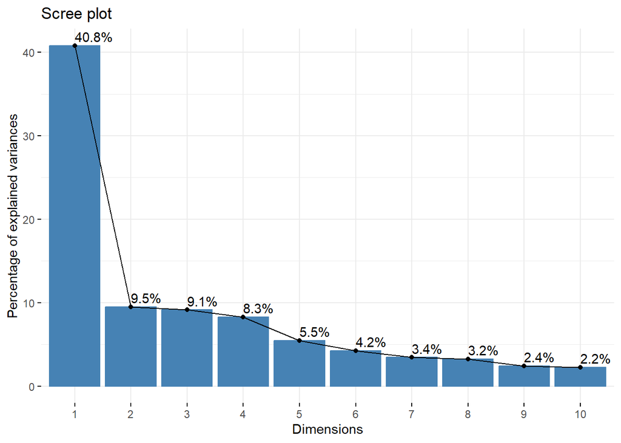

```r
fviz_eig(data_pca, addlabels = TRUE)
```

## Biplot

The correlation between a variable and a principal component (PC) is used as the coordinates of the variable on the PC. The representation of variables differs from the plot of the observations: The observations are represented by their projections, but the variables are represented by their correlations (Abdi and Williams 2010).

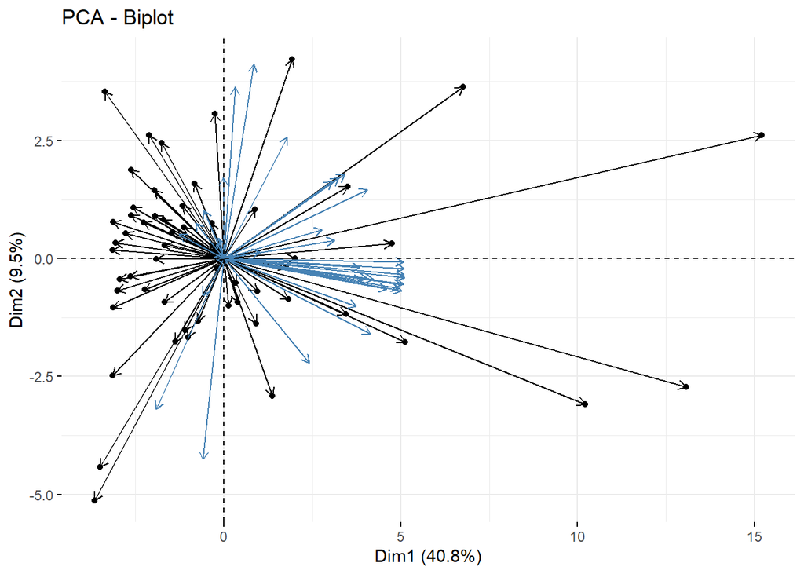

```r
fviz_pca_biplot(data_pca,
                geom = c("point", "arrow"),
                geom.var = "arrow")
```

## Correlation Circle

The plot below is also known as variable correlation plots. It shows the relationships between all variables. It can be interpreted as follow:

- Positively correlated variables are grouped together.
- Negatively correlated variables are positioned on opposite sides of the plot origin (opposed quadrants).
- The distance between variables and the origin measures the quality of the variables on the factor map. Variables that are away from the origin are well represented on the factor map.

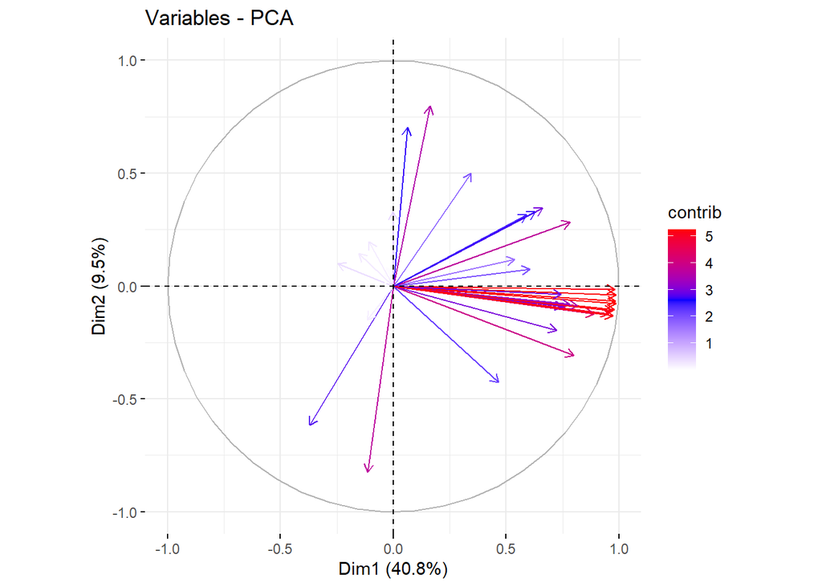

```r
# Control variable colors using their contributions
fviz_pca_var(data_pca, col.var = "contrib",
   gradient.cols = c("white", "blue", "red"),
   geom.var = "arrow",
   ggtheme = theme_minimal())
```

## Variable Contribution

Top variable contribution for the first two principal components.

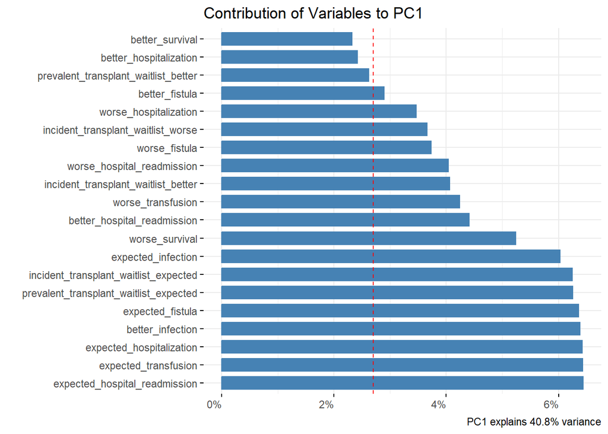

```r
# Contributions of variables to PC1
pc2_contribution <- fviz_contrib(data_pca, choice = "var", axes = 1, top = 20)

# Modify the theme to rotate X-axis labels to 90 degrees
pc2_contribution +
  theme(
    axis.text.x = element_text(angle = 0),
    plot.title = element_text(hjust = 0)  # horizontal justification
  ) +
  coord_flip() +
  labs(title = "Contribution of Variables to PC1",
       y = "Percentage Contribution",
       x = "",
       caption = "PC1 explains 40.8% variance") +
  scale_y_continuous(labels = scales::percent_format(scale = 1,
                                                     accuracy = 1))
```

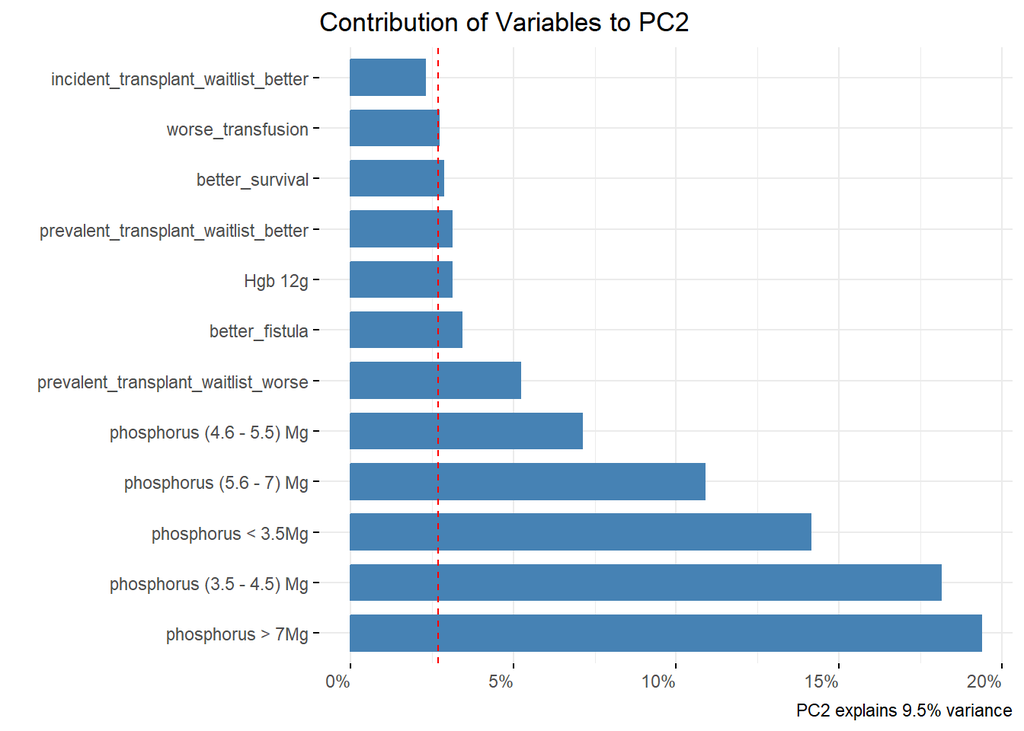

```r
# Contributions of variables to PC2
pc2_contribution <- fviz_contrib(data_pca, choice = "var", axes = 2, top = 12)

# Modify the theme to rotate X-axis labels to 90 degrees
pc2_contribution +
  theme(
    axis.text.x = element_text(angle = 0),
    plot.title = element_text(hjust = 0)  # horizontal justification
  ) +
  coord_flip() +
  labs(title = "Contribution of Variables to PC2",
       y = "Percentage Contribution",
       x = "",
       caption = "PC2 explains 9.5% variance") +
  scale_y_continuous(labels = scales::percent_format(scale = 1,
                                                     accuracy = 1))
```

# 06 - Model Building

## Data Splitting into Training & Test set

```r
# reproducible random sampling
set.seed(my_seed)

# Create Target y-variable for the training set
y <- train_data$expected_survival
# Split the data into training and test sets
split <- sample.split(y, SplitRatio = 0.7)
training_set <- subset(train_data, split == TRUE)
test_set <- subset(train_data, split == FALSE)
```

## Feature Scaling: Standardization

- It is important to Mean-Center the data prior to PCA model building to ensure the first Principal Component is in the direction of maximum variance.
- Standardization produces Mean = 0, and Variance = 1.

```r
# Feature Scaling: Standardization
# Perform centering and scaling on the training and test sets
sc <- preProcess(training_set[, -target_index],
                 method = c("center", "scale"))
training_set[, -target_index] <- predict(
  sc, training_set[, -target_index])
test_set[, -target_index] <- predict(sc, test_set[, -target_index])

# training_set[,-target_index] = scale(training_set[, -target_index])
# test_set[,-target_index] = scale(test_set[, -target_index])
```

## Applying PCA to Training & Test sets

```r
# Perform Principal Component Analysis (PCA) preprocessing on the training data
pca <- preProcess(training_set[, -target_index],
                  method = 'pca', pcaComp = 8)

# Apply PCA transformation to original training set
training_set <- predict(pca, training_set)

# Reorder columns, moving the dependent feature index to the end
training_set <- training_set[c(2:9, 1)]

# Apply PCA transformation to original test set
test_set <- predict(pca, test_set)

# Reorder columns, moving the dependent feature index to the end
test_set <- test_set[c(2:9, 1)]
```

## PRESS & Predicted R^2 Functions

```r
#PRESS - predicted residual sums of squares
PRESS <- function(linear.model) {
  # calculate the predictive residuals
  pr <- residuals(linear.model)/(1-lm.influence(linear.model)$hat)
  # calculate the PRESS
  PRESS <- sum(pr^2)

  return(PRESS)
}

pred_r_squared <- function(linear.model) {
  # Use anova() to get the sum of squares for the linear model
  lm.anova <- anova(linear.model)
  # Calculate the total sum of squares
  tss <- sum(lm.anova$'Sum Sq')
  # Calculate the predictive R^2
  pred.r.squared <- 1-PRESS(linear.model)/(tss)

  return(pred.r.squared)
}
```

## PCA Full Model - 8 Principal Components

```r
# reproducible random sampling
set.seed(my_seed)

# Fit a multiple linear regression model
pca_full_model <- lm(expected_survival ~ ., data = training_set)

# Print a summary of the regression model
summary(pca_full_model)
```

```
Call:
lm(formula = expected_survival ~ ., data = training_set)

Residuals:
    Min      1Q  Median      3Q     Max
-36.203  -9.273   2.228   6.583  35.083

Coefficients:
            Estimate Std. Error t value Pr(>|t|)
(Intercept)  97.0513     2.8389  34.187  < 2e-16 ***
PC1          29.4050     0.7133  41.222  < 2e-16 ***
PC2           4.5890     1.3329   3.443  0.00172 **
PC3          -1.1111     1.6420  -0.677  0.50381
PC4           4.9871     1.7472   2.854  0.00775 **
PC5          -3.2728     2.2463  -1.457  0.15552
PC6           6.9790     2.4355   2.866  0.00754 **
PC7          -6.6036     2.5605  -2.579  0.01505 *
PC8           3.8007     2.8211   1.347  0.18799
---
Signif. codes:  0 '***' 0.001 '**' 0.01 '*' 0.05 '.' 0.1 ' ' 1

Residual standard error: 17.73 on 30 degrees of freedom
Multiple R-squared:  0.983, Adjusted R-squared:  0.9785
F-statistic: 217.3 on 8 and 30 DF,  p-value: < 2.2e-16
```

```r
# Calculate PRESS
cat("PRESS: ", PRESS(pca_full_model), "\n")
```

```
PRESS:  31662.39
```

```r
# Calculate predicted R^2
cat("Predicted R^2: ", pred_r_squared(pca_full_model), "\n")
```

```
Predicted R^2:  0.9430373
```

### Visualization of Uncorrelated PCA Matrix

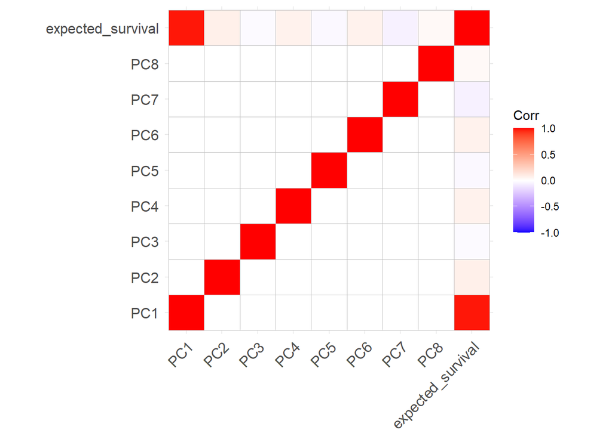

```r
# Visual of Principal Components un-correlation
corr_matrix <- cor(training_set)
ggcorrplot(corr_matrix)
```

## PCA - 2 Principal Components

```r
# Create a subset with 2 principal components
significant_pcs = c(1,2,9)
train_pca <- training_set[, significant_pcs]
test_pca <- test_set[, significant_pcs]
```

```r
# reproducible random sampling
set.seed(my_seed)

# Fit a multiple linear regression model
reg_model <- lm(expected_survival ~ .,
                data = train_pca)

# Print a summary of the regression model
summary(reg_model)
```

```
Call:
lm(formula = expected_survival ~ ., data = train_pca)

Residuals:
    Min      1Q  Median      3Q     Max
-71.156  -9.381  -3.187   8.080  59.653

Coefficients:
            Estimate Std. Error t value Pr(>|t|)
(Intercept)  97.0513     3.5849  27.073  < 2e-16 ***
PC1          29.4050     0.9008  32.644  < 2e-16 ***
PC2           4.5890     1.6832   2.726  0.00983 **
---
Signif. codes:  0 '***' 0.001 '**' 0.01 '*' 0.05 '.' 0.1 ' ' 1

Residual standard error: 22.39 on 36 degrees of freedom
Multiple R-squared:  0.9675,    Adjusted R-squared:  0.9657
F-statistic: 536.5 on 2 and 36 DF,  p-value: < 2.2e-16
```

```r
# Calculate PRESS
cat("PRESS: ", PRESS(reg_model), "\n")
```

```
PRESS:  25699.6
```

```r
# Calculate predicted R^2
cat("Predicted R^2: ", pred_r_squared(reg_model), "\n")
```

```
Predicted R^2:  0.9537647
```

## **Principal Components Regression**

- PCA is used to calculate principal components that can then be used in principal components regression. This type of regression is often used when multicollinearity exists between predictors in a data set.

```r
# reproducible random sampling
set.seed(my_seed)

y = train_pca$expected_survival

# fit PCR
pcr_model <- pcr(y ~ PC1+PC2, data=train_pca, validation="CV")

summary(pcr_model)
```

```
Data:   X dimension: 39 2
    Y dimension: 39 1
Fit method: svdpc
Number of components considered: 2

VALIDATION: RMSEP
Cross-validated using 10 random segments.
       (Intercept)  1 comps  2 comps
CV           122.5    36.39    24.27
adjCV        122.5    34.68    24.11

TRAINING: % variance explained
   1 comps  2 comps
X    77.74   100.00
y    96.08    96.75
```

## Repeated Cross-Validation

```r
# reproducible random sampling
set.seed(my_seed)

# Repeated cross-validation with 5 folds, 3 repetitions
train_control <- trainControl(method = "repeatedcv",
                                            number = 10, repeats = 3)

# training the model
model_cv_repeat <- train(expected_survival ~ .,
                         data = train_pca,
                         method = "lm",
                         trControl = train_control)


# Print Overall Model Performance
print(model_cv_repeat)
```

```
Linear Regression

39 samples
 2 predictor

No pre-processing
Resampling: Cross-Validated (10 fold, repeated 3 times)
Summary of sample sizes: 35, 35, 35, 35, 35, 35, ...
Resampling results:

  RMSE      Rsquared   MAE
  21.19074  0.9728849  16.05276

Tuning parameter 'intercept' was held constant at a value of TRUE
```

## Cross-Validation

```r
# reproducible random sampling
set.seed(my_seed)

# Cross-validation with n folds
k_10 <- trainControl(method = "cv", number = 10)

# training the model
model_cv <- train(expected_survival ~ .,
                  data = train_pca,
                  method = "lm",
                  trControl = k_10)

# Print Model Performance
print(model_cv)
```

```
Linear Regression

39 samples
 2 predictor

No pre-processing
Resampling: Cross-Validated (10 fold)
Summary of sample sizes: 35, 35, 35, 35, 35, 35, ...
Resampling results:

  RMSE     Rsquared   MAE
  21.7825  0.9761582  16.14872

Tuning parameter 'intercept' was held constant at a value of TRUE
```

```r
cv_results = model_cv$results
```

# 07 - Predictions

```r
# Find the index position of the target feature
pred_target_index <- grep(target_name,
                     colnames(test_pca))
cat("Target Feature Index =", pred_target_index)
```

```
Target Feature Index = 3
```

```r
# Create Predicted Target Feature (y-test)
y_test <- test_pca[pred_target_index]
```

```r
# Predictions using the Cross-Validation model
y_pred = predict(model_cv, newdata = test_pca[, -pred_target_index])
```

```r
# Prediction Results from y_predictions
round(y_pred, digits = 0)
```

```
  9  11  12  16  17  18  21  23  25  26  28  40  43  47  48  52  53
 35 520 310  26 298 125 159 149 191  81   2  86 113 182 585  33  88
```

```r
# Transform y_test from data frame to numeric
y_test_numeric <- as.numeric(unlist(y_test))

# Original data
y_test_numeric
```

```
 [1]  16 442 318  25 284 152 160 141 197  95   2  78  38 171 657   7  92
```

## Prediction Metrics

```r
# Calculate Mean Absolute Error (MAE)
mae_value <- mae(y_pred, y_test_numeric)
cat("MAE =", mae_value)
```

```
MAE = 21.90924
```

```r
# Calculate MSE
mse_predict <- mean((y_pred - y_test_numeric)^2)
cat("\nMSE =", mse_predict)
```

```
MSE = 1140.189
```

```r
# Calculate RMSE
rmse_predict <- sqrt(mean((y_pred - y_test_numeric)^2))
cat("\nRMSE =", rmse_predict)
```

```
RMSE = 33.76669
```

```r
# Calculate R-squared (R^2)
predicted_r2 <- 1 - sum((y_test_numeric - y_pred)^2) /
  sum((y_test_numeric - mean(y_test_numeric))^2)
cat("\nPredicted R^2 =", predicted_r2)
```

```
Predicted R^2 = 0.9600483
```

# 08 - Training Conclusion

In conclusion, this project has demonstrated the effectiveness of Principal Component Analysis (PCA) in dimension reduction with the following key points:

- PCA was able to reduce from 37 features down to just 2 principal components.
- The best score of R^2 = 97.61% was from the Linear Regression with Cross-validation model.
- The predicted R^2 = 96%
- The average deviation between the predicted values, and observed values for ‘Expected Survival’ is RMSE = 33.77.
- The model has not been exposed to unseen data with a large amount of observations to asses its robustness, and reliability.